```python
import pandas as pd
import matplotlib.pyplot as plt
import numpy
from sklearn import linear_model
import seaborn as sns
from sklearn import datasets
from statsmodels.formula.api import ols
from sklearn.linear_model import LinearRegression
import statsmodels.api as sm
import sklearn.datasets
import sklearn.linear_model as lm
from numpy import array

data = pd.read_csv("gap.tsv", sep='\t')
data.head()
```

|  | country | continent | year | lifeExp | pop | gdpPercap |
| --- | --- | --- | --- | --- | --- | --- |
| 0 | Afghanistan | Asia | 1952 | 28.801 | 8425333 | 779.445314 |
| 1 | Afghanistan | Asia | 1957 | 30.332 | 9240934 | 820.853030 |
| 2 | Afghanistan | Asia | 1962 | 31.997 | 10267083 | 853.100710 |
| 3 | Afghanistan | Asia | 1967 | 34.020 | 11537966 | 836.197138 |
| 4 | Afghanistan | Asia | 1972 | 36.088 | 13079460 | 739.981106 |

# Part 1 Exercise 1

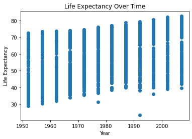

```python
%matplotlib inline
x = data['year']
y = data['lifeExp']
plt.scatter(x, y)
plt.xlabel("Year")
plt.ylabel("Life Expectancy")
plt.title("Life Expectancy Over Time")
```

# Part 1 Question 1

The general trend of the scatter plot is that life expectancy increases across time. One can see that the highest life expectancy in 1952 is around 74 and this increases to around 84 in 2007. The trend seems to be linear.

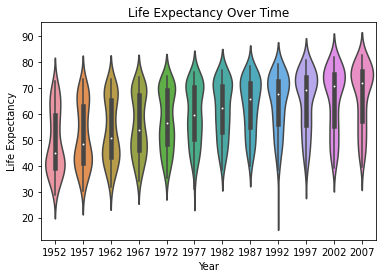

```python
sns.violinplot(x = 'year', y = 'lifeExp', data = data)
plt.title("Life Expectancy Over Time")
plt.xlabel("Year")
plt.ylabel("Life Expectancy")
```

# Part 1 Question 2

The distribution is skewed. In the earlier years, the distribution is skewed towards the bottom, meaning there were more people who had a lower life expectancy. Across time, the distribution skews towards the top, meaning more people had a higher life expectancy. Since it does not have a normal distribution, it is not symmetric. It is not unimodal since there are more than one modes for some years.

# Part 1 Question 3

I would reject the null hypothesis. The null hypothesis would be that there is no correlation between life expectancy and year, but there is clearly a relationship between the two, so the null hypothesis would be rejected.

# Part 1 Question 4

The violin plot for the residuals would look linear, since it is from the linear model. This means that the slope would be the same throughout the data.

# Part 1 Question 5

Based on assumptions of the linear model, the distribution would appear normal. The plot would appear Gaussian with zero mean.

# Part 1 Exercise 2

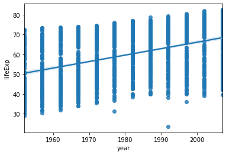

```python
sns.regplot(x = "year", y = "lifeExp", data = data)
```

# Part 1 Question 6

On average, the life expectancy increases 0.3259 years every year.

```python
ans = ols(formula = "lifeExp ~ year", data = data).fit()
print(ans.summary())
```

```
                            OLS Regression Results
==============================================================================
Dep. Variable:                lifeExp   R-squared:                       0.190
Model:                            OLS   Adj. R-squared:                  0.189
Method:                 Least Squares   F-statistic:                     398.6
Date:                Fri, 04 Dec 2020   Prob (F-statistic):           7.55e-80
Time:                        02:33:27   Log-Likelihood:                -6597.9
No. Observations:                1704   AIC:                         1.320e+04
Df Residuals:                    1702   BIC:                         1.321e+04
Df Model:                           1
Covariance Type:            nonrobust
==============================================================================
                 coef    std err          t      P>|t|      [0.025      0.975]
------------------------------------------------------------------------------
Intercept   -585.6522     32.314    -18.124      0.000    -649.031    -522.273
year           0.3259      0.016     19.965      0.000       0.294       0.358
==============================================================================
Omnibus:                      386.124   Durbin-Watson:                   0.197
Prob(Omnibus):                  0.000   Jarque-Bera (JB):               90.750
Skew:                          -0.268   Prob(JB):                     1.97e-20
Kurtosis:                       2.004   Cond. No.                     2.27e+05
==============================================================================

Warnings:
[1] Standard Errors assume that the covariance matrix of the errors is correctly specified.
[2] The condition number is large, 2.27e+05. This might indicate that there are
strong multicollinearity or other numerical problems.
```

# Part 1 Question 7

Yes, I reject the null hypothesis that there is no relationship between life expectancy and year because the p-value is 0, meaning there is stronger evidence that the alternative hypothesis should be accepted.

# Part 1 Exercise 3

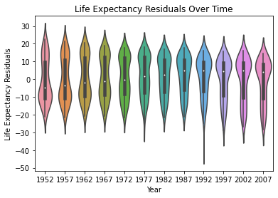

```python
slope = ans.params.year
a = ans.params.Intercept

data['expected'] = 0
for i, row in data.iterrows():
    exp = slope * (row['year']) + a
    data.at[i, 'expected'] = exp  #adds expected values to data
data['residuals'] = data['lifeExp'] - data['expected'] #creates residuals column and subtracts expected data from actual data

sns.violinplot(x = 'year', y = 'residuals', data = data) #creates violin plot
plt.title("Life Expectancy Residuals Over Time")
plt.xlabel("Year")
plt.ylabel("Life Expectancy Residuals")
```

# Part 1 Question 8

# Part 1 Exercise 4

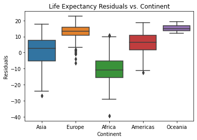

```python
sns.boxplot(x = 'continent', y = 'residuals', data = data)
plt.xlabel("Continent")
plt.ylabel("Residuals")
plt.title("Life Expectancy Residuals vs. Continent")
```

# Part 1 Question 9

There is dependence between model residual and continent since each continent has different boxes and values. It suggests that the continent affects the life expectancy over time.

# Part 1 Exercise 5

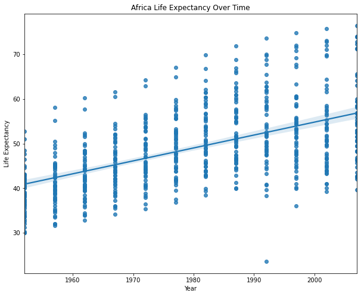

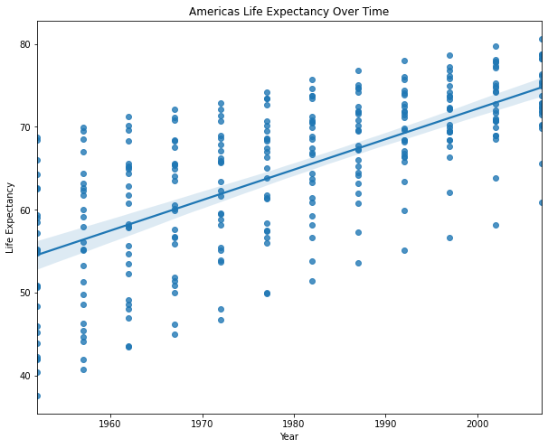

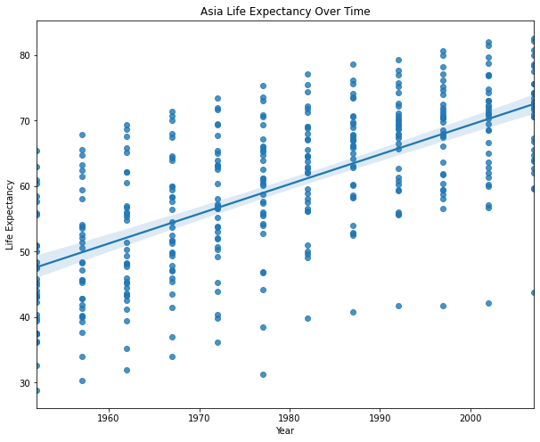

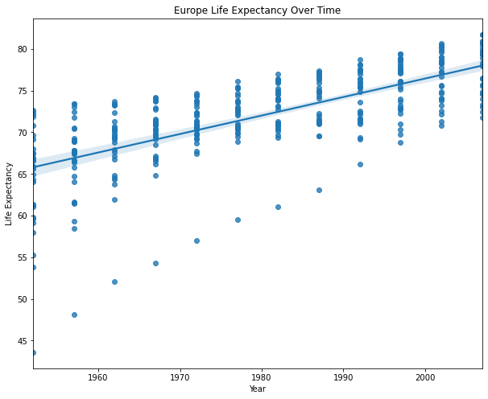

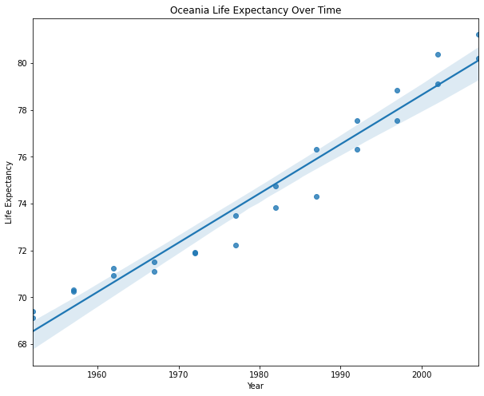

```python
continent = numpy.unique(data['continent']) #list of unique continents

for cont in continent: #loops through each continent
    dropped_data = data.drop(data[cont != data['continent']].index) #drops data not from the current continent cont
    plt.figure(figsize = (10, 8))
    sns.regplot(x = "year", y = "lifeExp", data = dropped_data) #creates plot
    plt.title(cont + " Life Expectancy Over Time")
    plt.xlabel("Year")
    plt.ylabel("Life Expectancy")
```

# Part 1 Question 10

Yes, the regression model should include an interaction term for continent and year because the data is varied for each continent, showing that the continent affects the life expectancy over time.

# Part 1 Exercise 6

```python
continent_values = data['continent'].values
new_array = [] #new array
for x in continent_values: #associates indices for each continent
    if x == 'Africa':
        new_array.append(1)
    elif x == 'Americas':
        new_array.append(2)
    elif x == 'Asia':
        new_array.append(3)
    elif x == 'Europe':
        new_array.append(4)
    else:
        new_array.append(5)
data['continent_index'] = pd.Series(new_array, index = data.index)
regression = ols(formula='lifeExp ~ year * continent', data=data).fit()
regression.summary()
```

OLS Regression Results

| Dep. Variable: | lifeExp | R-squared: | 0.693 |
| --- | --- | --- | --- |
| Model: | OLS | Adj. R-squared: | 0.691 |
| Method: | Least Squares | F-statistic: | 424.3 |
| Date: | Fri, 04 Dec 2020 | Prob (F-statistic): | 0.00 |
| Time: | 02:33:29 | Log-Likelihood: | -5771.9 |
| No. Observations: | 1704 | AIC: | 1.156e+04 |
| Df Residuals: | 1694 | BIC: | 1.162e+04 |
| Df Model: | 9 |  |  |
| Covariance Type: | nonrobust |  |  |

|  | coef | std err | t | P>\|t\| | [0.025 | 0.975] |
| --- | --- | --- | --- | --- | --- | --- |
| Intercept | -524.2578 | 32.963 | -15.904 | 0.000 | -588.911 | -459.605 |
| continent[T.Americas] | -138.8484 | 57.851 | -2.400 | 0.016 | -252.315 | -25.382 |
| continent[T.Asia] | -312.6330 | 52.904 | -5.909 | 0.000 | -416.396 | -208.870 |
| continent[T.Europe] | 156.8469 | 54.498 | 2.878 | 0.004 | 49.957 | 263.737 |
| continent[T.Oceania] | 182.3499 | 171.283 | 1.065 | 0.287 | -153.599 | 518.298 |
| year | 0.2895 | 0.017 | 17.387 | 0.000 | 0.257 | 0.322 |
| year:continent[T.Americas] | 0.0781 | 0.029 | 2.673 | 0.008 | 0.021 | 0.135 |
| year:continent[T.Asia] | 0.1636 | 0.027 | 6.121 | 0.000 | 0.111 | 0.216 |
| year:continent[T.Europe] | -0.0676 | 0.028 | -2.455 | 0.014 | -0.122 | -0.014 |
| year:continent[T.Oceania] | -0.0793 | 0.087 | -0.916 | 0.360 | -0.249 | 0.090 |

| Omnibus: | 27.121 | Durbin-Watson: | 0.242 |
| --- | --- | --- | --- |
| Prob(Omnibus): | 0.000 | Jarque-Bera (JB): | 44.106 |
| Skew: | -0.121 | Prob(JB): | 2.65e-10 |
| Kurtosis: | 3.750 | Cond. No. | 2.09e+06 |

Warnings:  
[1] Standard Errors assume that the covariance matrix of the errors is correctly specified.  
[2] The condition number is large, 2.09e+06. This might indicate that there are  
strong multicollinearity or other numerical problems.

# Part 1 Question 11

Without an interaction period, all of the parameters are significantly different from 0, since all of their p values are less than 0.05. With the interaction period, all of the parameters are significantly different from 0 except Oceania which has a p-value of 0.360, meaning it is not significantly different from 0.

# Part 1 Question 12

```python
regression.params
```

```
Intercept                    -524.257846
continent[T.Americas]        -138.848447
continent[T.Asia]            -312.633049
continent[T.Europe]           156.846852
continent[T.Oceania]          182.349883
year                            0.289529
year:continent[T.Americas]      0.078122
year:continent[T.Asia]          0.163593
year:continent[T.Europe]       -0.067597
year:continent[T.Oceania]      -0.079257
dtype: float64
```

# Part 1 Exercise 8

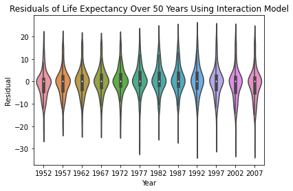

```python
cols = data[['continent', 'year', 'lifeExp']];
cols = cols.sort_values(by='continent').reset_index(drop=True)

#stores slopes and intercepts for each continent
year = regression.params[5]
intercept = regression.params[0]
slope_americas = year + regression.params[6]
intercept_americas = intercept + regression.params[1]
slope_asia = year + regression.params[7]
intercept_asia = intercept + regression.params[2]
slope_europe = year + regression.params[8]
intercept_europe = intercept + regression.params[3]
slope_oceania = year + regression.params[9]
intercept_oceania = intercept + regression.params[4]


cols['residual'] = 0

cols['residual'][cols['continent'] == 'Africa']  = cols['lifeExp'] - ((year*cols['year'])+intercept)
cols['residual'][cols['continent'] == 'America'] = cols['lifeExp'] - ((slope_americas*cols['year'])+intercept_americas)
cols['residual'][cols['continent'] == 'Asia']    = cols['lifeExp'] - ((slope_asia*cols['year'])+intercept_asia)
cols['residual'][cols['continent'] == 'Europe']  = cols['lifeExp'] - ((slope_europe*cols['year'])+intercept_europe)
cols['residual'][cols['continent'] == 'Oceania'] = cols['lifeExp'] - ((slope_oceania*cols['year'])+intercept_oceania)

sns.violinplot(x='year', y='residual', data=cols);
plt.xlabel('Year')
plt.ylabel('Residual')
plt.title('Residuals of Life Expectancy Over 50 Years Using Interaction Model')
```

It fits the assumptions because the plot appears Gaussian and it is normally distributed.

# Part 2 Problem 1

```python
#linear
def gradient_descent(X, y, T, alpha):
    loss = numpy.zeros(T)   # loss over time
    a, b = X.shape       # a is the # of examples, b is the # of features
    theta = numpy.zeros(b)  # initialize parameters

    for i in range(T):  #iterates num_steps times
        loss[i] = 0.5*numpy.linalg.norm(X.dot(theta) - y)**2 # cost for current parameter
        grad = X.T.dot(X.dot(theta) - y) #compute ascent with highest slope
        theta = theta - alpha*grad #go down the gradient
    return theta, loss
```

# Part 2 Problem 2

Derivation:

A generic loss function, C (sum of each cost): $$C = \sum_{i=1}^{n} cost(p_i(\beta^k), y_i)$$

y would either be 0 or 1, so new loss function: $$ cost(p(\beta^k), y) = -ylog(p(\beta^k)) - (1-y)log(1-p(\beta^k))$$

The logit function: $$p_i(\beta^k) = \frac{e^{f_i(\beta^k)}}{1+e^{f_i(\beta^k)}} * \frac{1+e^{-f_i(\beta^k)}}{1+e^{-f_i(\beta^k)}} = \frac{e^{f_i(\beta^k)}+1}{(e^{f_i(\beta^k)}+1)(1+e^{-f_i(\beta^k)})} = \frac{1}{(1+e^{-f_i(\beta^k)})} $$

The loss function: $$-\sum_{i=1}^{n} y log(p(\beta^k)) + (1-y)log(1-p(\beta^k))$$

The derivative of the logit: $$ p(\beta^k)(1-p(\beta^k)) * f'(\beta^k) $$

To minimize the convex cost, the gradient for linear regression will be used. L = argument of the summation: $$L(\beta^k) = y log(p(\beta^k)) + (1-y)log(1-p(\beta^k))$$ $$ \frac{\partial}{\partial \beta^k}L(\beta^k) = y * \frac{1}{p(\beta^k)} * p'(\beta^k) + (1-y) * \frac{1}{1-p(\beta^k)} * -p'\beta^k $$ $$ = \bigg(\frac{y}{p(\beta^k)} - \frac{1-y}{1-p(\beta^k)}\bigg)p'\beta^k $$

$$ = \bigg(\frac{y}{p(\beta^k)} - \frac{1-y}{1-p(\beta^k)}\bigg)(p(\beta^k)(1-p(\beta^k)) * f'(\beta^k))$$$$ = \Big(y(1-p(\beta^k)) - (1-y)(p(\beta^k))\Big)x_i$$$$ = (y - p(\beta^k))x_i$$

Using the gradient, the parameters are updated. The equation: $$ \theta_{n+1} = \theta{n} - \alpha \cdot \nabla $$ Since there is a negative outside of the summation, there is a double negative which cancels. New equation: $$\beta^{k+1} = \beta^{k} + \alpha\sum_{i=1}^{n}(y_i - p_i(\beta^k))x_i$$

# Part 2 Problem 3

```python
#logistic batch version
#p_i(b^k)
def logit(x):
    return (numpy.exp(x)/(1+numpy.exp(x)))

def log_gradient_descent(X, y, T, alpha):
    loss = numpy.zeros(T)  # loss over time
    a, b = X.shape # a is the # of examples, b is the # of features
    theta = numpy.zeros(b)

    for i in range(T): #iterates num_steps times
        res = logit(X.dot(theta))
        loss[i] = (numpy.log(1+numpy.exp(res.dot(y)))) # cost for current parameter
        res2 = X.T.dot(res-y) #compute ascent with highest slope
        theta = theta + alpha*res2 #go down the gradient
    return theta, loss
```

# Part 2 Problem 4

```python
#data for linear regression
gen_data_x, gen_data_y, coef = \
sklearn.datasets.make_regression(n_samples=100, n_features=20, noise = 1.5, coef=True)

#data for logistic regression with values of either 0 or 1
log_gen_data_x, dump_y, log_coef = \
sklearn.datasets.make_regression(n_samples=100, n_features=20, noise = 1.5, coef=True)
log_gen_data_y = [0 if i>0 else 1 for i in dump_y]
```

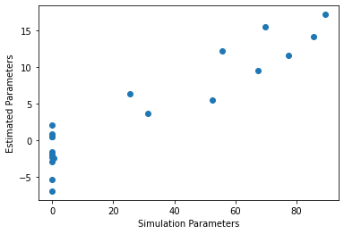

```python
theta, cost = gradient_descent(gen_data_x, gen_data_y, 2000, .000001)

plt.scatter(coef,theta)
plt.xlabel('Simulation Parameters')
plt.ylabel('Estimated Parameters')
```

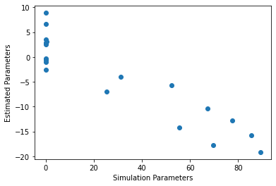

```python
theta, cost = log_gradient_descent(gen_data_x, gen_data_y, 2000, .000001)

plt.scatter(coef,theta)
plt.xlabel('Simulation Parameters')
plt.ylabel('Estimated Parameters')
```

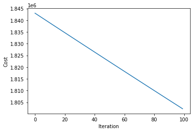

```python
theta, cost = gradient_descent(gen_data_x, gen_data_y, 100, .000001)
plt.plot(numpy.arange(100), cost)
plt.xlabel('Iteration')
plt.ylabel('Cost')
plt.show()
```

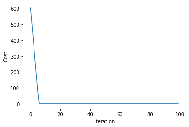

```python
theta, cost = log_gradient_descent(gen_data_x, gen_data_y, 100, .000001)
plt.plot(numpy.arange(100), cost)
plt.xlabel('Iteration', fontsize=10)
plt.ylabel('Cost', fontsize=10)
plt.show()
```

# Try it Out

The dataset that I am using is the wine dataset from sklearn. I am predicting which class the wine belongs to, class_0, class_1, or class_2. There are 13 attributes the wine has. The two algorithms I'm using are Random Forests and k-NN classification.

```python
from sklearn.datasets import load_wine
from sklearn.ensemble import RandomForestClassifier    #Random Forest
from sklearn.model_selection import train_test_split, KFold, cross_val_score
from sklearn.model_selection import RepeatedKFold
from sklearn.metrics import mean_squared_error
import numpy

#loads wine dataset
wine = load_wine()

#Random Forests
from sklearn.ensemble import RandomForestClassifier    #Random Forest

X_train, X_test, y_train, y_test = train_test_split(wine.data, wine.target, random_state=34)
forest = RandomForestClassifier(n_estimators=100, random_state=0, max_features='sqrt')

crossScores = cross_val_score(forest, X_train, y_train, cv=10) #trains and fits classifier using CV test

#training accuracy scored, informed by 10 trials
print('Accuracy: %.3f (%.3f)' % (crossScores.mean(), crossScores.std()))

forest.fit(X_train,y_train)
print(forest.score(X_test,y_test)) #testing accuracy
```

```
Accuracy: 0.985 (0.031)
0.9777777777777777
```

```
0.7333333333333333
Accuracy: 0.748 (0.095)
```

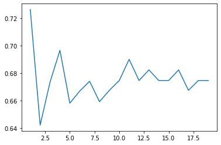

```python
from sklearn.neighbors import KNeighborsClassifier     #KNN
# k-NN classification
X_train, X_test, y_train, y_test = \
train_test_split(wine.data, wine.target, stratify=wine.target, random_state=42)
kf = KFold(n_splits=10)
test_accuracy = []

#algorithm for different k nearest neighbor from range of 1-20
neighbors_range = range(1,20)

for n_neighbors in neighbors_range:
    knn = KNeighborsClassifier(n_neighbors=n_neighbors)
    k_fold_training_accuracy = []
    for train, test in kf.split(X_train):
        knn.fit(X_train[train],y_train[train])
        k_fold_training_accuracy.append(knn.score(X_train[test], y_train[test]))
    test_accuracy.append(numpy.mean(k_fold_training_accuracy))

plt.plot(range(1,20), test_accuracy)
#In the plot, the best k value is 1
best_values = KNeighborsClassifier(n_neighbors=1)
best_values.fit(X_train,y_train)
print(best_values.score(X_test, y_test))

# To get the general accuracy score informed by 10 trials
scores = cross_val_score(best_values, wine.data, wine.target, cv=10)
print('Accuracy: %.3f (%.3f)' % (scores.mean(), scores.std()))
```

```python
def logit(x):
    return (numpy.exp(x)/(1+numpy.exp(x)))

def score_log_reg(y_pred,y_test):
    count = 0
    length = 0
    for a ,b in zip(y_predict, y_test):
        if a ==b:
            count+=1
        length+=1
    #score:
    return count/length

# Batch version of logistic gradient descent.
def log_grad_descent(X, y, T, alpha):
    a, b = X.shape
    theta = numpy.zeros(b)
    cost = numpy.zeros(T)

    for i in range(T):
        p = logit(X.dot(theta))
        cost[i] = (numpy.log(1+numpy.exp(p.dot(y))))
        g = X.T.dot(p-y)
        theta = theta + alpha*g
    return theta, cost

X_train, X_test, y_train, y_test = train_test_split(wine.data, wine.target, random_state=34)
T = 100000
alpha = .0000000000005
theta, f = log_grad_descent(X_train, y_train, T, alpha )

y_predict = list(logit(X_test.dot(theta)).round())

print(score_log_reg(list(logit(X_train.dot(theta)).round()), y_train)) #training accuracy
print(score_log_reg(y_predict, y_test)) #accuracy
```

```
0.4222222222222222
0.35555555555555557
```

```python
from scipy import stats
#10 fold cross validation
score= []
kf = KFold(n_splits=10)
for train, test in kf.split(wine.data):
    theta, f = log_grad_descent(wine.data[train], wine.target[train], T, alpha)
    y_predict = list(logit(wine.data[test].dot(theta)).round())
    score.append(score_log_reg(y_predict, wine.target[test]))
    #print(stats.ttest_rel(train, test))

print(numpy.mean(score)) #score from doing cross validation
```

```
0.3277777777777778
```